# CERF data workup

Kim Cressman

2017-11-03

## Background

This project started out with the objective of combining NERRS and IOOS data to analyze inshore-to-offshore gradients of storm effects.

I was not able to find IOOS stations offshore near Gulf Coast NERRS (though there are some good regional monitoring programs already looking at inshore-to-offshore gradients - SCCF’s RECON network in the Caloosahatchee River and Estuary; Mobile Bay NEP/DISL’s network). But spatial and temporal differences can be pulled out of multiple stations in a different way, and be applied to similar data integration projects in the future - hopefully with less effort than this initial workup.

Load packages

```r
library(tidyverse)
library(reshape2)
library(lubridate)
library(htmlTable)
library(shape)
library(RColorBrewer)
library(knitr)
```

## Analysis of storm effects, using NERRS and IOOS data

There are several steps involved in analyzing storm effects. I’ll step through them in detail in this file; here is the summary.

### Data Download

**NERRS data**: I used the “Custom Query” option from the CDMO’s Advanced Query System (http://cdmo.baruch.sc.edu/aqs/) to download WQ and MET data from all stations at all 5 Gulf of Mexico Reserves, from 5/1/2017 - 10/30/2017. This was delivered in one CSV file, which I named “nerrs.csv”.

**IOOS data**: I used the GCOOS data portal to find stations that had water level and/or salinity data in gaps between NERRS. I ended up downloading data from two NOAA Tides and Currents stations; one in Texas, near Houston (NOS 8770613), and one in Louisiana (NOS 8764314). It was surprisingly difficult to find the data; there was no direct link that I could find from the GCOOS portal. I did get enough information to google the stations and find them. Data through Tides and Currents can only be downloaded a month at a time, and there are three separate data types to deal with, so I figured out the url pattern for each type (MET, water level, and temp/conductivity), copied and pasted, changed the dates, changed the stations, and downloaded everything in one run of the script `Data downloads`. I then used the script `Data concatination` to glue all of those NOS files together, and exported a CSV that I named “NOS_all.csv”.

### Data processing

Data files from all stations were combined, and many exploratory graphs were generated, in `CERF workup.Rmd`. I eventually decided to take a deep dive into data from Tropical Storm Cindy in the northern Gulf, because I have NERR and IOOS-discovered stations that showed conductivity effects from the storm.

I subsetted the wq and met files to include only the following stations; all data through 9/1/17 are included.

- apadbwq
- apapcwq
- apaebmet
- gndbcwq
- gndblwq
- gndcrmet
- la_nos (this has both wq and met)
- wkbfrwq
- wkbwbwq
- wkbshmet

### Load and prep data

Three data frames were saved together and will be opened here:

- wq_cindy_ngom
- met_cindy_ngom
- storm_info

```r
load("dat_cindy_ngom.R")
kable(storm_info)
```

| storm_name | baseline_start | storm_start | storm_end | post_end |
| --- | --- | --- | --- | --- |
| Cindy | 2017-06-06 | 2017-06-20 | 2017-06-23 | 2017-07-07 |
| Emily | 2017-07-17 | 2017-07-31 | 2017-08-01 | 2017-08-15 |
| Harvey | 2017-08-03 | 2017-08-17 | 2017-08-31 | 2017-09-14 |
| Irma | 2017-08-16 | 2017-08-30 | 2017-09-12 | 2017-09-26 |
| Nate | 2017-09-20 | 2017-10-04 | 2017-10-09 | 2017-10-23 |

#### Label pre-storm period, storm period, and post-storm period.

Cindy was a named storm from 6/20/2017 to 6/23/2017. Turn these labels into an ordered factor (pre – storm – post).

Also turn stationcode into a factor so stations will be arranged from west to east.

```r
wq_cindy_ngom$period <- ifelse(wq_cindy_ngom$datetimestamp < "2017-06-20", "pre",
                             ifelse(wq_cindy_ngom$datetimestamp > "2017-06-23", "post",
                                    "storm"))
wq_cindy_ngom$period <- factor(wq_cindy_ngom$period, c("pre", "storm", "post"))
wq_cindy_ngom$stationcode <- factor(wq_cindy_ngom$stationcode, c("la_nos", "gndblwq", "gndbcwq", "wkbwbwq", "wkbfrwq", "apapcwq", "apadbwq"))


met_cindy_ngom$period <- ifelse(met_cindy_ngom$datetimestamp < "2017-06-20", "pre",
                             ifelse(met_cindy_ngom$datetimestamp > "2017-06-23", "post",
                                    "storm"))
met_cindy_ngom$period <- factor(met_cindy_ngom$period, c("pre", "storm", "post"))
met_cindy_ngom$stationcode <- factor(met_cindy_ngom$stationcode, c("la_nos", "gndcrmet", "wkbshmet", "apaebmet"))
```

#### Trim and peek at the data

I’m keeping a month on either side of the storm. I am also copying water level data from the Louisiana NOS station into the depth column, to match NERR data.

```r
start <- storm_info$baseline_start[storm_info$storm_name=="Cindy"]
wq <- wq_cindy_ngom %>%
    filter(datetimestamp >= "2017-05-20 0:00",
           datetimestamp < "2017-07-23 23:45") %>%
    mutate(depth = ifelse(!is.na(depth), depth, level))
met <- met_cindy_ngom %>%
    filter(datetimestamp >= "2017-05-20 0:00",
           datetimestamp < "2017-07-23 23:45")



kable(head(wq))
```

| datetimestamp | stationcode | sal | depth | level | temp | spcond | period |
| --- | --- | --- | --- | --- | --- | --- | --- |
| 2017-05-20 05:00:00 | apadbwq | 20.8 | 1.68 | NA | NA | 33.33 | pre |
| 2017-05-20 05:00:00 | apapcwq | 31.9 | 1.81 | NA | NA | 48.98 | pre |
| 2017-05-20 05:00:00 | gndbcwq | 12.8 | 0.68 | NA | NA | 21.46 | pre |
| 2017-05-20 05:00:00 | gndblwq | 16.7 | 0.66 | NA | NA | 27.30 | pre |
| 2017-05-20 05:00:00 | wkbfrwq | 0.5 | 2.20 | NA | NA | 1.02 | pre |
| 2017-05-20 05:00:00 | wkbwbwq | 6.2 | 0.71 | NA | NA | 10.97 | pre |

```r
kable(head(met))
```

| datetimestamp | stationcode | atemp | rh | bp | wspd | maxwspd | wdir | totprcp | period |
| --- | --- | --- | --- | --- | --- | --- | --- | --- | --- |
| 2017-05-20 05:00:00 | apaebmet | 26.2 | 89 | 1016 | 3.0 | 4.1 | 125 | 0 | pre |
| 2017-05-20 05:00:00 | gndcrmet | 26.3 | 85 | 1014 | 8.4 | 10.2 | 138 | 0 | pre |
| 2017-05-20 05:00:00 | wkbshmet | NA | NA | NA | NA | NA | NA | NA | pre |
| 2017-05-20 05:15:00 | apaebmet | 26.3 | 89 | 1016 | 3.6 | 5.3 | 121 | 0 | pre |
| 2017-05-20 05:15:00 | gndcrmet | 26.3 | 85 | 1014 | 8.2 | 9.8 | 142 | 0 | pre |
| 2017-05-20 05:15:00 | wkbshmet | NA | NA | NA | NA | NA | NA | NA | pre |

### Pull out baseline info on conductivity

```r
wq_pre <- wq %>%
    filter(period == "pre") %>%
    mutate(month = month(datetimestamp),
           day = day(datetimestamp),
           year = year(datetimestamp),
           yymmdd = ymd_hm(paste0(year, "-", month, "-", day, " 12:00"))) %>%
    select(stationcode, yymmdd, spcond) %>%
    group_by(stationcode, yymmdd) %>%
    summarize(daily_min = min(spcond, na.rm=TRUE),
              daily_mean = mean(spcond, na.rm=TRUE),
              daily_max = max(spcond, na.rm=TRUE))

wq_storm <- wq %>%
    filter(period == "storm") %>%
    mutate(month = month(datetimestamp),
           day = day(datetimestamp),
           year = year(datetimestamp),
           yymmdd = ymd_hm(paste0(year, "-", month, "-", day, " 12:00"))) %>%
    select(stationcode, yymmdd, spcond) %>%
    group_by(stationcode, yymmdd) %>%
    summarize(daily_min = min(spcond, na.rm=TRUE),
              daily_mean = mean(spcond, na.rm=TRUE),
              daily_max = max(spcond, na.rm=TRUE))

wq_post <- wq %>%
    filter(period == "post") %>%
    mutate(month = month(datetimestamp),
           day = day(datetimestamp),
           year = year(datetimestamp),
           yymmdd = ymd_hm(paste0(year, "-", month, "-", day, " 12:00"))) %>%
    select(stationcode, yymmdd, spcond) %>%
    group_by(stationcode, yymmdd) %>%
    summarize(daily_min = min(spcond, na.rm=TRUE),
              daily_mean = mean(spcond, na.rm=TRUE),
              daily_max = max(spcond, na.rm=TRUE))
```

#### Plot it

Facets are stacked from west at the top to east at the bottom.

Thin, colored lines are 15-minute (NERRS) or hourly (NOS) data.

Thick lines are daily averages. Red is the time period that the named storm existed (6/20-6/23). Black is one month on either side.

The thin vertical line is the date of landfall (6/22).

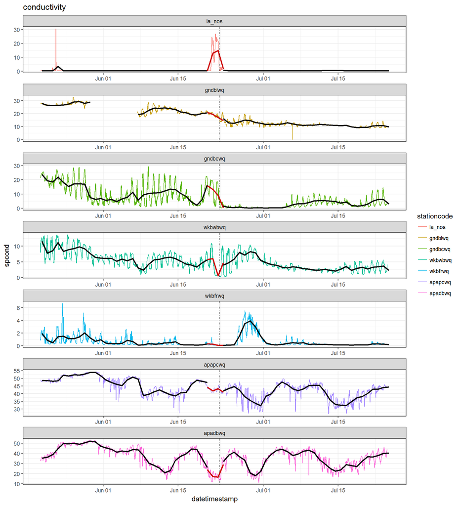

```r
landfall <- as.numeric(as.POSIXct("2017-06-22 12:00"))

ggplot() +
    geom_line(data=wq, aes(x=datetimestamp, y=spcond, col=stationcode)) +
    geom_line(data=wq_pre, aes(x=yymmdd, y=daily_mean), col="black", lwd=1) +
    geom_line(data=wq_storm, aes(x=yymmdd, y=daily_mean), col="red3", lwd=1) +
    geom_line(data=wq_post, aes(x=yymmdd, y=daily_mean), col="black", lwd=1) +
    geom_vline(data=wq, aes(xintercept = landfall), lty=4, col="black") +
    facet_wrap( ~stationcode, ncol=1, scales="free") +
    theme_bw() +
    ggtitle("conductivity")
```

### Do all this with depth because it might show more info

```r
wq_pre <- wq %>%
    filter(period == "pre") %>%
    mutate(month = month(datetimestamp),
           day = day(datetimestamp),
           year = year(datetimestamp),
           yymmdd = ymd_hm(paste0(year, "-", month, "-", day, " 12:00"))) %>%
    select(stationcode, yymmdd, depth) %>%
    group_by(stationcode, yymmdd) %>%
    summarize(daily_min = min(depth, na.rm=TRUE),
              daily_mean = mean(depth, na.rm=TRUE),
              daily_max = max(depth, na.rm=TRUE))

wq_storm <- wq %>%
    filter(period == "storm") %>%
    mutate(month = month(datetimestamp),
           day = day(datetimestamp),
           year = year(datetimestamp),
           yymmdd = ymd_hm(paste0(year, "-", month, "-", day, " 12:00"))) %>%
    select(stationcode, yymmdd, depth) %>%
    group_by(stationcode, yymmdd) %>%
    summarize(daily_min = min(depth, na.rm=TRUE),
              daily_mean = mean(depth, na.rm=TRUE),
              daily_max = max(depth, na.rm=TRUE))

wq_post <- wq %>%
    filter(period == "post") %>%
    mutate(month = month(datetimestamp),
           day = day(datetimestamp),
           year = year(datetimestamp),
           yymmdd = ymd_hm(paste0(year, "-", month, "-", day, " 12:00"))) %>%
    select(stationcode, yymmdd, depth) %>%
    group_by(stationcode, yymmdd) %>%
    summarize(daily_min = min(depth, na.rm=TRUE),
              daily_mean = mean(depth, na.rm=TRUE),
              daily_max = max(depth, na.rm=TRUE))
```

#### Plot it

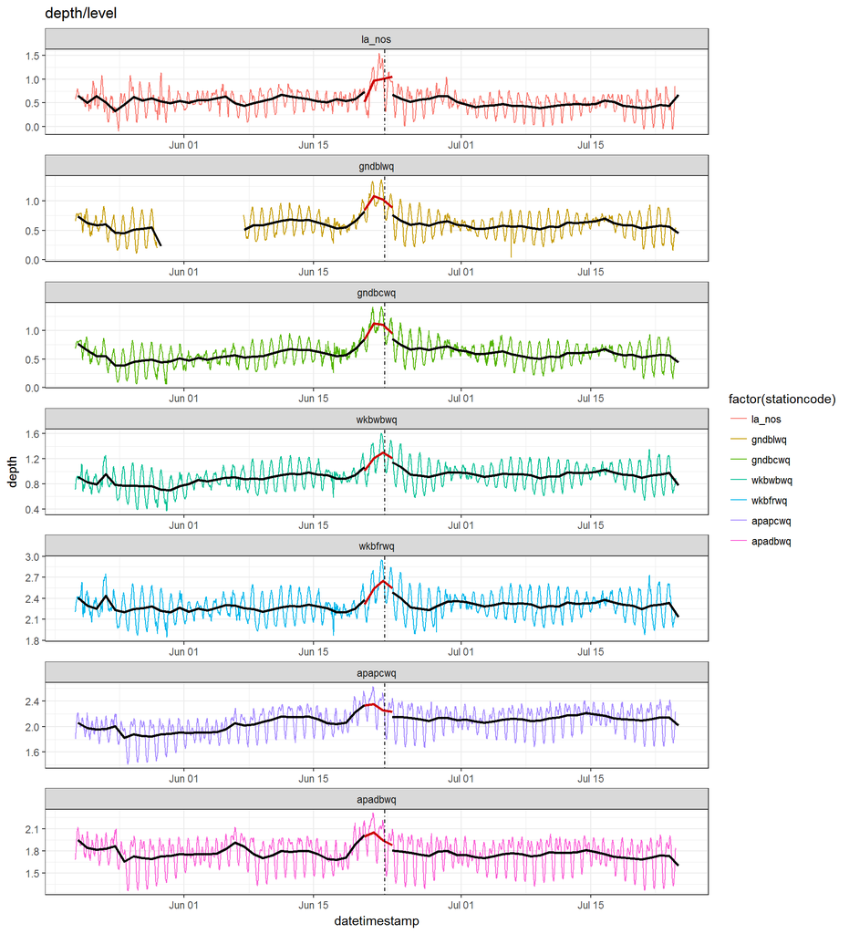

```r
ggplot() +
    geom_line(data=wq, aes(x=datetimestamp, y=depth, col=factor(stationcode))) +
    geom_line(data=wq_pre, aes(x=yymmdd, y=daily_mean), col="black", lwd=1) +
    geom_line(data=wq_storm, aes(x=yymmdd, y=daily_mean), col="red3", lwd=1) +
    geom_line(data=wq_post, aes(x=yymmdd, y=daily_mean), col="black", lwd=1) +
    geom_vline(data=wq, aes(xintercept = landfall), lty=4, col="black") +
    facet_wrap( ~stationcode, ncol=1, scales="free") +
    theme_bw() +
    ggtitle("depth/level")
```